# Assignment 4

Author

Published

November 20, 2024

# Instructions

Please submit your assignment as html file to me via email. Please call your assignment: “yourname_assignment4.html”. For example, I would submit something called “popescu_assignment4.html”. Please make sure that it is all in lower case.

To match the appearance of this template, ensure that your assignment preamble or YAML is set up as follows

```
---
title: "Assignment 4"
author: "Your Name"
date: "November 20, 2024"
format:
  html:
    toc: true
    number-sections: true
    colorlinks: true
    smooth-scroll: true
    embed-resources: true
---
```

Important: Headers like “Question” should be marked with a `#` (for example, `# Question`). This will format the text as a bold, larger header when the document is rendered, and it will also appear in the Table of Contents. For regular text, simply write it on the line below the header.

Please answer all the questions below.

# 1 Introduction

In this hypothetical situation (the data is made up, i.e. does not exist), Carrefour Rome is planning on launching a coupon program designed to increase revenue by providing discount coupon for purchases over 40 euros. So they have funding to run a randomized controlled trial (RCT) in some stores They selected about a 70% of their stores in Rome and they want to investigate whether offering coupons has any effect on revenue.

Thus, we want to calculate $E(\text{Post-Treatment revenue | Coupon})$

In a first instance, we create the relationship among the many different variables:

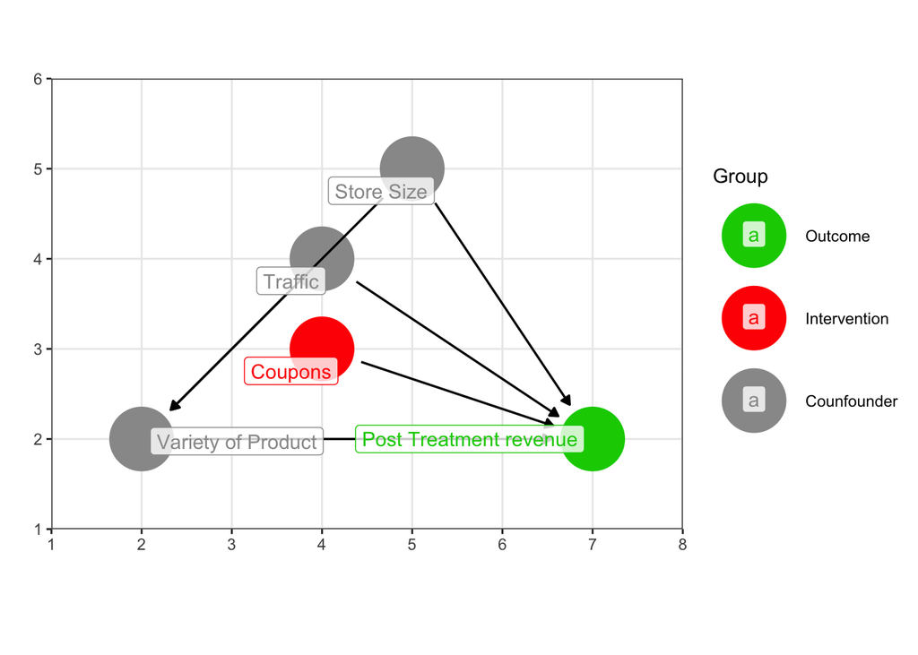

# 2 Inspecting the Area

Let’s assume that the experiment has been conducted and the data has come in. Let us first have a first look at the area where Carrefour ran the experiment.

```
[1] "Carrefour Iper"    "Carrefour Market"  "Carrefour Express"
```

[interactive chart not shown]

# Question 1

Produce the same map in leaflet.

```r
library("leaflet")
library("leaflegend")

#name <- colorFactor(topo.colors(3), domain = carrefour$name)
pal <-
   colorFactor(palette = c("blue", "red", "purple"),
               levels = c("Carrefour Express", "Carrefour Market", "Carrefour Iper"))


leaflet(carrefour) %>% addTiles() %>%
  addCircleMarkers(lng = ~lon_x, lat = ~lat_y,
             popup = ~address, radius = 4, color = ~pal(name))%>%
  addLegendFactor(
    pal=pal,
    values = carrefour$name,
    position = 'topright',
    shape = 'circle',
    width = 10,
    height = 10,
    opacity = .5)%>%
  addScaleBar(
  position = c("bottomright"))
```

[interactive chart not shown]

# Question 2

Open the data and map the stores and the roads. Use different colors for the three different types of stores in the data.

- [RCT Data](https://www.dropbox.com/s/qak8d1d63wcaf8u/carrefour.csv?dl=0)
- Spatial Data on [roads](https://www.dropbox.com/sh/ye8zvl0qwcnu8ph/AACoKp6PyE8PgXWMtZKa5s6za?dl=0) from the Rome Area

```r
#Reading the data
library(sf)
carrefour <- read.csv(file = './rct_data.csv')
roads<- st_read("./rome_center_roads/gis_osm_roads_free_selection.shp", quiet = TRUE)

roads<-st_read("/Users/bgpopescu/Dropbox/john_cabot/teaching/stats/assignment4/centro-latest-free/gis_osm_roads_free_selection.shp", quiet = TRUE)

min_lon_x<-min(carrefour$lon_x)
max_lon_x<-max(carrefour$lon_x)

min_lat_y<-min(carrefour$lat_y)
max_lat_y<-max(carrefour$lat_y)
```

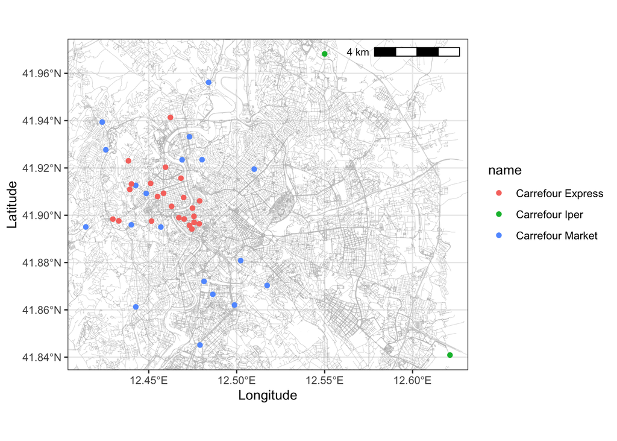

# Question 3

Create a static map that displays the stores that got treated vs. not.

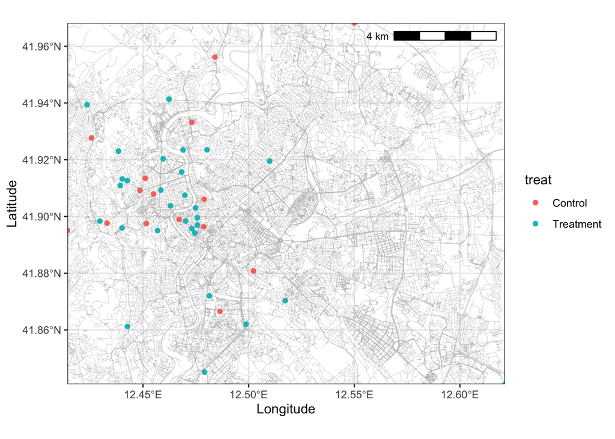

```r
ggplot()+
  geom_sf(data = roads, color = "grey", linewidth=0.1)+
    geom_point(data = carrefour, aes(x=lon_x, y=lat_y, color = treat))+
    coord_sf(xlim = c(min_lon_x, max_lon_x), ylim = c(min_lat_y, max_lat_y), expand = FALSE)+
        ggspatial::annotation_scale(location = 'tr')+
    theme_bw()+
  labs(x = "Longitude", y="Latitude")
```

# Question 4

Create a summary statistics for the data and comment on the skewness or normality.

Unique

Missing Pct.

Mean

SD

Min

Median

Max

Histogram

lat_y

44

0

41.9

0.0

41.8

41.9

42.0

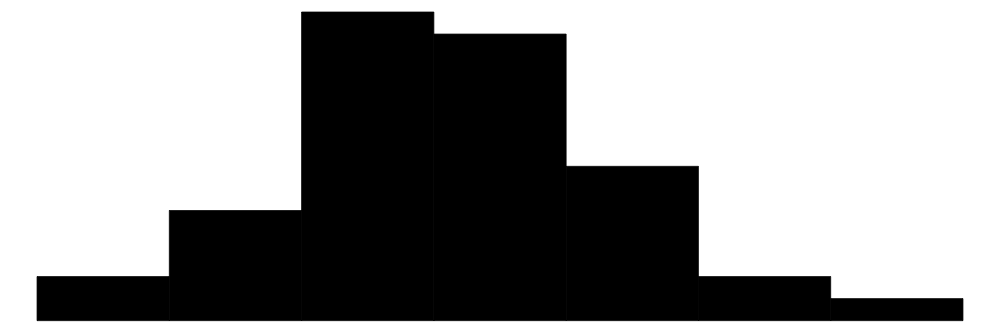

lon_x

44

0

12.5

0.0

12.4

12.5

12.6

[figure not shown]

id

44

0

22.5

12.8

1.0

22.5

44.0

[figure not shown]

variety_products

44

0

84.3

36.9

6.2

79.8

196.6

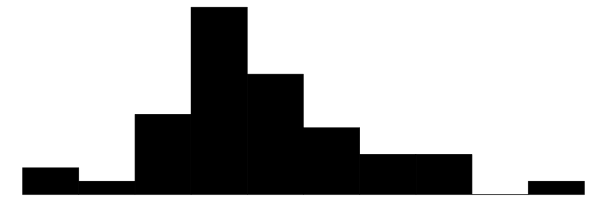

store_size

44

0

405.2

263.6

74.0

356.0

1094.0

[figure not shown]

traffic

44

0

1556.8

1276.1

34.0

1273.0

5932.0

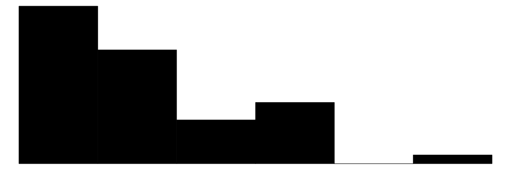

coupon

2

0

0.7

0.5

0.0

1.0

1.0

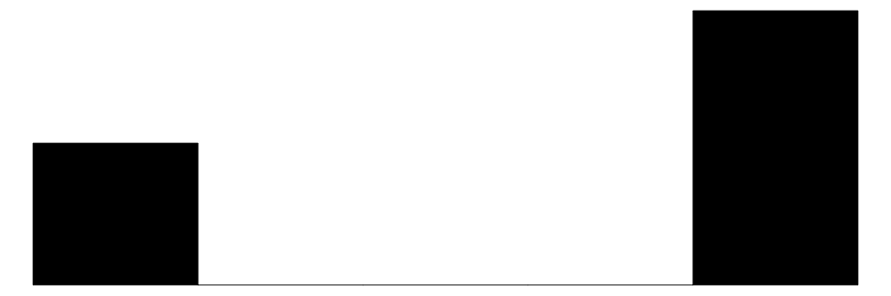

revenue_pre

44

0

49928.7

22211.2

10000.0

45058.7

100000.0

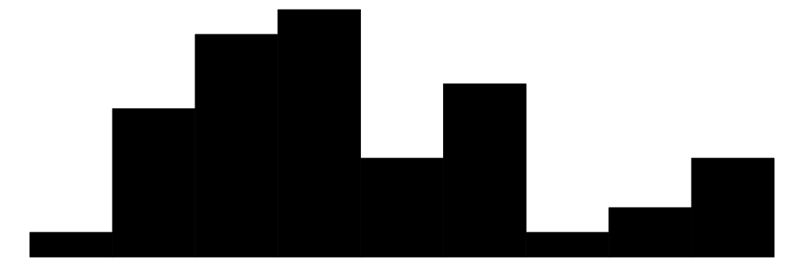

revenue_post

44

0

52372.3

23998.8

10000.0

55046.8

100000.0

[figure not shown]

N

%

name

Carrefour Express

23

52.3

Carrefour Iper

2

4.5

Carrefour Market

19

43.2

address

CIRCONVALLAZIONE TRIONFALE,112 - ROMA (RM)

1

2.3

CORSO VITTORIO EMANUELE II, 286-288-290 - ROMA (RM)

1

2.3

LARGO LORIA N. 6 - ROMA (RM)

1

2.3

LARGO LUCIO APULEIO 10 - ROMA (RM)

1

2.3

P.LE DEGLI EROI - ROMA (RM)

1

2.3

P.LE MORELLI N. 52 - ROMA (RM)

1

2.3

PIAZZA BENEDETTO CAIROLI 13 - ROMA (RM)

1

2.3

PIAZZA IRNERIO 51/52 - ROMA (RM)

1

2.3

PIAZZA NICOSIA,35 - ROMA (RM)

1

2.3

V.LE GERMANIA - ROMA (RM)

1

2.3

VIA AJACCIO N.29-31-35-37-39 - ROMA (RM)

1

2.3

VIA ALESIA 35/37 - ROMA (RM)

1

2.3

VIA APPIANO 31 - ROMA (RM)

1

2.3

VIA AURELIA 350 - ROMA (RM)

1

2.3

VIA BUFALOTTA - ROMA (RM)

1

2.3

VIA CESARE BARONIO N. 161/165 - ROMA (RM)

1

2.3

VIA CESARE FRACASSINI 62 - ROMA (RM)

1

2.3

VIA DEL BISCIONE 79 - ROMA (RM)

1

2.3

VIA DEL GESU', 57-58-59 - ROMA (RM)

1

2.3

VIA DEL GOVERNO VECCHIO 119 - ROMA (RM)

1

2.3

VIA DELL'ACQUEDOTTO DEL PESCHIERA DAL N.22 AL 30/A - ROMA (RM)

1

2.3

VIA DELLA BALDUINA 217 - ROMA (RM)

1

2.3

VIA DELLA CROCE 48 - ROMA (RM)

1

2.3

VIA DELLA PINETA SACCHETTI, 199 - ROMA (RM)

1

2.3

VIA DELLE FORNACI DAL N. 136 AL N. 154 - ROMA (RM)

1

2.3

VIA DI PORTA CASTELLO 10 - ROMA (RM)

1

2.3

VIA E.DONATO N.27 - ROMA (RM)

1

2.3

VIA FLAMINIA KM. 8,200 - ROMA (RM)

1

2.3

VIA GIACOMO BOVE, 4, 4/A, 4/C, 4/D, 4E, 16 - ROMA (RM)

1

2.3

VIA GIOVANNI NICOTERA 13/27 - ROMA (RM)

1

2.3

VIA GIUSTINIANI 15B - ROMA (RM)

1

2.3

VIA GREGORIO VII - ROMA (RM)

1

2.3

VIA GREGORIO XI N.201/209 - ROMA (RM)

1

2.3

VIA IGNAZIO PERSICO N.82 - ROMA (RM)

1

2.3

VIA L.SCHIAVONETTI N.420-426-432 - ROMA (RM)

1

2.3

VIA LAURENTINA 84 - ROMA (RM)

1

2.3

VIA LUCREZIO CARO,43 - ROMA (RM)

1

2.3

VIA MONTE DEL GALLO 9-13B - ROMA (RM)

1

2.3

VIA MONTE PERTICA,27 - ROMA (RM)

1

2.3

VIA MONTERONE,8 - ROMA (RM)

1

2.3

VIA MONTICELLI N. 9/21 - ROMA (RM)

1

2.3

VIA ORTI DELLA FARNESINA, 83-85-87- - ROMA (RM)

1

2.3

VIA SEBASTIANO VENIERO, 10/A-12-14-16 - ROMA (RM)

1

2.3

VIALE GIULIO CESARE 143 - ROMA (RM)

1

2.3

treat

Control

15

34.1

Treatment

29

65.9

```r
datasummary_skim(carrefour)
```

# Question 5

What is the percentage of stores that received the treatment?

```r
stores_randomized<-carrefour %>%
  dplyr::count(coupon) %>%
  mutate(prop = n / sum(n))
stores_randomized
```

| coupon | n | prop |
| --- | --- | --- |
| 0 | 15 | 0.3409091 |
| 1 | 29 | 0.6590909 |

# Question 6

Create graphs that compare the pointrange for the treatment and control groups for the following variables:

- variety of products
- store size
- traffic
- pre-treatment income

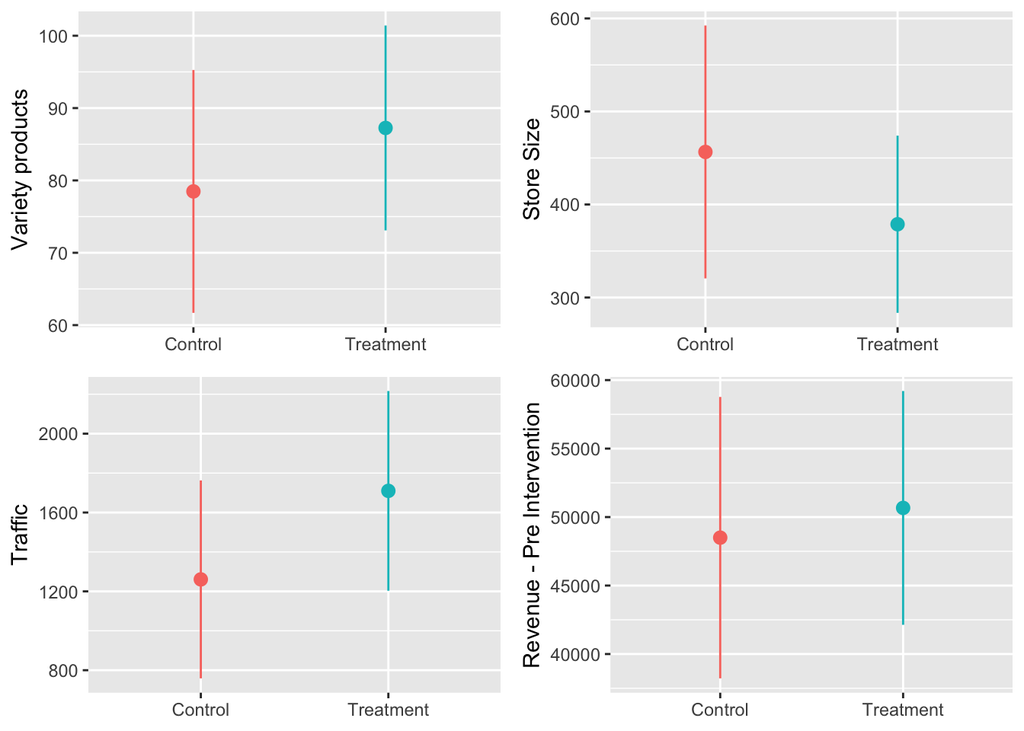

```r
plot_variety_products <- ggplot(carrefour, aes(x = treat, y = variety_products, color = treat)) +
  stat_summary(geom = "pointrange", fun.data = "mean_se", fun.args = list(mult = 1.96)) +
  guides(color = "none") +
  labs(x = NULL, y = "Variety products")

plot_store_size <- ggplot(carrefour, aes(x = treat, y = store_size, color = treat)) +
  stat_summary(geom = "pointrange", fun.data = "mean_se", fun.args = list(mult = 1.96)) +
  guides(color = "none") +
  labs(x = NULL, y = "Store Size")

plot_traffic <- ggplot(carrefour, aes(x = treat, y = traffic, color = treat)) +
  stat_summary(geom = "pointrange", fun.data = "mean_se", fun.args = list(mult = 1.96)) +
  guides(color = "none") +
  labs(x = NULL, y = "Traffic")


plot_revenue_pre <- ggplot(carrefour, aes(x = treat, y = revenue_pre, color = treat)) +
  stat_summary(geom = "pointrange", fun.data = "mean_se", fun.args = list(mult = 1.96)) +
  guides(color = "none") +
  labs(x = NULL, y = "Revenue - Pre Intervention")

ggarrange(plot_variety_products, plot_store_size,
          plot_traffic, plot_revenue_pre, ncol=2, nrow=2, common.legend = TRUE)
```

# Question 7

Create graphs that compare the distributions for the treatment and control groups for the following variables:

- variety of products
- store size
- traffic
- pre-treatment income

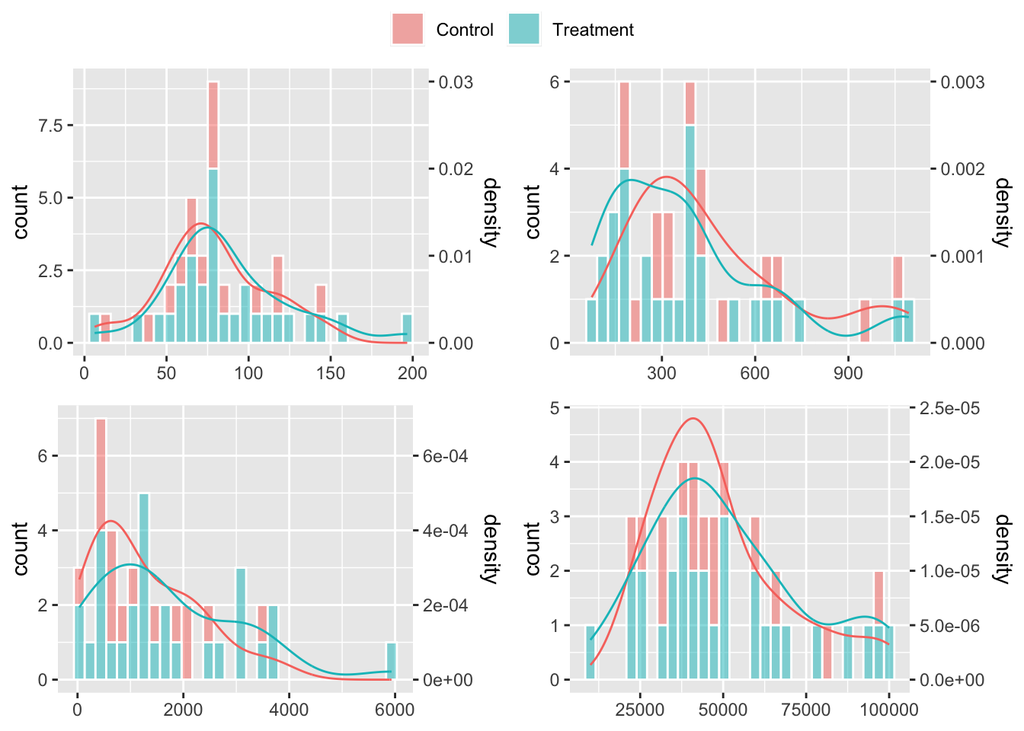

```r
plot_diff_variety_products_d<-ggplot(carrefour, aes(x = variety_products, fill = treat, group=treat)) +
  guides(color = "none", alpha=0.5) +
  geom_histogram(color = "white",
                 alpha = 0.5)+
  #Adding density and multiplying by a manually defined value
  #for visibility
  geom_density(aes(y = after_stat(density)* 300, color=treat),
               #alpha = 0.5,
               fill=NA)+
  #Adding a secondary axis
  scale_y_continuous(name = "count",
                     sec.axis =
                       sec_axis(~.x/300,
                                name = "density"))+
  labs(fill = NULL)+
  xlab(NULL)

plot_diff_store_size_d<-ggplot(carrefour, aes(x = store_size, fill = treat, group=treat)) +
  guides(color = "none") +
  geom_histogram(color = "white", alpha=0.5)+
  #Adding density and multiplying by a manually defined value
  #for visibility
  geom_density(aes(y = after_stat(density)* 2000, color=treat),
               #alpha = 0.5,
               fill=NA)+
  #Adding a secondary axis
  scale_y_continuous(name = "count",
                     sec.axis =
                       sec_axis(~.x/2000,
                                name = "density"))+
  labs(fill = NULL)+
  xlab(NULL)

plot_diff_traffic_d<-ggplot(carrefour, aes(x = traffic, fill = treat, group=treat)) +
  guides(color = "none") +
  geom_histogram(color = "white",
                 alpha = 0.5)+
  #Adding density and multiplying by a manually defined value
  #for visibility
  geom_density(aes(y = after_stat(density)* 10000, color=treat),
               #alpha = 0.5,
               fill=NA)+
  #Adding a secondary axis
  scale_y_continuous(name = "count",
                     sec.axis =
                       sec_axis(~.x/10000,
                                name = "density"))+
  labs(fill = NULL)+
  xlab(NULL)

plot_diff_revenue_pre_d<-ggplot(carrefour, aes(x = revenue_pre, fill = treat, group=treat)) +
    guides(color = "none") +
  geom_histogram(color = "white",
                 alpha = 0.5)+
  #Adding density and multiplying by a manually defined value
  #for visibility
  geom_density(aes(y = after_stat(density)* 200000, color=treat),
               #alpha = 0.5,
               fill=NA)+
  #Adding a secondary axis
  scale_y_continuous(name = "count",
                     sec.axis =
                       sec_axis(~.x/200000,
                                name = "density"))+
  labs(fill = NULL)+
  xlab(NULL)

ggarrange(plot_diff_variety_products_d, plot_diff_store_size_d,
          plot_diff_traffic_d, plot_diff_revenue_pre_d,
          ncol=2, nrow=2, common.legend = TRUE)
```

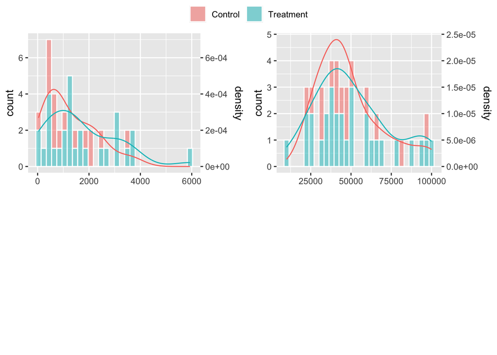

```r
ggarrange(
        plot_diff_traffic_d, plot_diff_revenue_pre_d,
          ncol=2, nrow=2, common.legend = TRUE)
```

# Question 8

Are the treatment and the control group the same on pre-treatment covariates? Perform adequate tests and interpret them?

```r
t.test(variety_products ~ coupon, data = carrefour, alternative=c("two.sided"))[3]
```

```
$p.value
[1] 0.4393249
```

```r
t.test(store_size ~ coupon, data = carrefour, alternative=c("two.sided"))[3]
```

```
$p.value
[1] 0.3666812
```

```r
t.test(traffic ~ coupon, data = carrefour, alternative=c("two.sided"))[3]
```

```
$p.value
[1] 0.2247868
```

```r
t.test(revenue_pre ~ coupon, data = carrefour, alternative=c("two.sided"))[3]
```

```
$p.value
[1] 0.7520119
```

The results are not statistically significant.

# Question 9

Estimate the difference: $E(\text{Post-revenue | Coupon})$. What is the ATE? Calculate the average between the treatment and control group using means.

```r
stores_randomized<-carrefour %>%
  group_by(treat) %>%
  summarize(avg_revenue_post = mean(revenue_post))
stores_randomized
```

| treat | avg_revenue_post |
| --- | --- |
| Control | 27285.94 |
| Treatment | 65347.96 |

That’s 65347.96 - 27285.94, or 38062.02, which means that the program caused an increase in revenue of 38062.02, on average.

# Question 10

Calculate the difference between treatment and control groups using a regression. Make sure that the variables are labelled appropriately.

```r
model_rct1 <- lm(revenue_post ~ treat, data = carrefour)

models<-list("Income" = model_rct1)

cm <- c('treatTreatment'='Offered Coupon (Treatment)',
        "(Intercept)"="Intercept")

modelsummary(models, stars = TRUE, coef_map = cm, gof_map = c("nobs", "r.squared"))
```

|  | Income |
| --- | --- |
| Offered Coupon (Treatment) | 38062.023*** |
|  | (5014.957) |
| Intercept | 27285.939*** |
|  | (4071.364) |
| Num.Obs. | 44 |
| R2 | 0.578 |

+ p < 0.1, * p < 0.05, ** p < 0.01, *** p < 0.001

# Question 11

Plot the differences in the distribution in income after the experiment between the treatment and the control group.

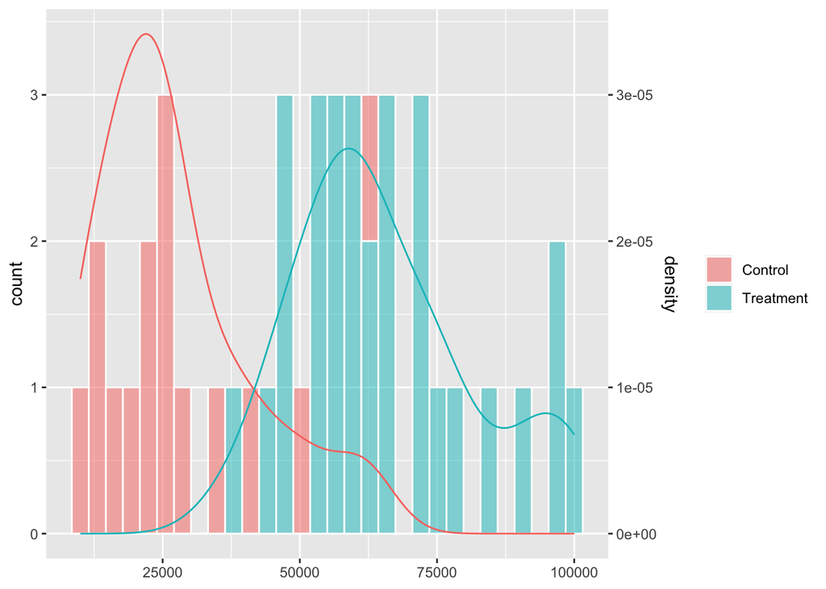

```r
ggplot(carrefour, aes(x = revenue_post, fill = treat, group=treat)) +
    guides(color = "none") +
  geom_histogram(color = "white",
                 alpha = 0.5)+
  #Adding density and multiplying by a manually defined value
  #for visibility
  geom_density(aes(y = after_stat(density)* 100000, color=treat),
               #alpha = 0.5,
               fill=NA)+
  #Adding a secondary axis
  scale_y_continuous(name = "count",
                     sec.axis =
                       sec_axis(~.x/100000,
                                name = "density"))+
  labs(fill = NULL)+
  xlab(NULL)
```

# Question 12

Plot the differences in the pointrange in income after the experiment between the treatment and the control group.

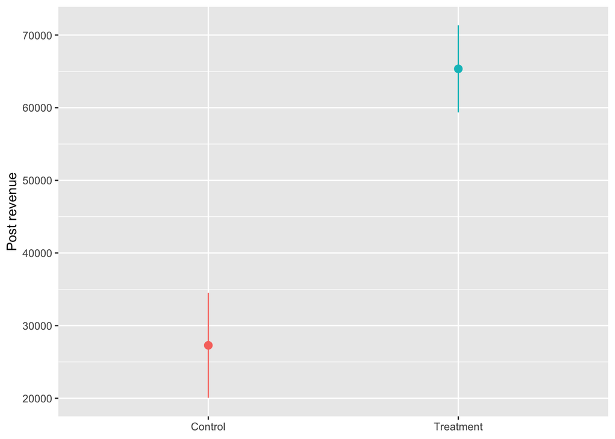

```r
ggplot(carrefour, aes(x = treat, y = revenue_post, color = treat)) +
  stat_summary(geom = "pointrange", fun.data = "mean_se", fun.args = list(mult = 1.96)) +
  guides(color = "none") +
  labs(x = NULL, y = "Post revenue")
```

# Question 13

What do you tell the Carrefour manager? Do the coupons work? Should Carrefour expand the coupon system?